# Ocean acidification in the continental margin of Portugal: filling gaps with old data

Nils Lucas Jacobsen, Marcos Fontela

17 June, 2021

# PM trends step 1 - Preparation, carbon computations, and preliminary analysis

### Defining study area

```r
ABasin <- data.frame(lon = c(-13, -7), lat = c(36, 42))  # Defining the geographical region
```

### Loading and filtering GLODAP data

```r
A <- readMat('GLODAPv2.2020_Atlantic_Ocean.mat')
# Keep the expocodes and their correspondence with G2cruise (expocodeno)
expocodes <- data.frame(); expocodes <- as.data.frame(unlist(A$expocode))
expocodes[, 2] <- as.data.frame(unlist(A$expocodeno))
names(expocodes) <- c("expocode", "expocodeno")
A <- A %>% list.remove(c("expocode", "expocodeno")) %>% as.data.frame()

# Filter for geographical area, remove NAs in salinity and potential temperature, and add data soucre
A <- A %>%
  filter(G2latitude >= (min(ABasin$lat)) & G2latitude <= (max(ABasin$lat))) %>%
  filter(G2longitude >= (min(ABasin$lon)) & G2longitude <= (max(ABasin$lon))) %>%
  mutate_all(.funs = funs(ifelse(. == "NaN", NA, .))) %>%
  filter((!is.na(G2salinity))) %>%
  filter((!is.na(G2theta))) %>%
  mutate(source = "GLODAP")

# Creating the zone variable based on latitude
A$zone <- ifelse(A$G2latitude > 40.1, "zone1",
                 ifelse(A$G2latitude < 40.1 & A$G2latitude > 37.2, "zone2",
                    ifelse(A$G2latitude < 37.2, "zone3", NA)))
```

### Carbon computations with GLODAP data

```r
A <- A %>%  # Adding flags for seacarb
  mutate(flag = ifelse(G2talkf == 2 & G2tco2f == 2, 15,  # Flag 15 Alk & DIC
                     ifelse(G2talkf == 2 & G2tco2f == 0 & G2phtsinsitutpf == 2, 8,  # Flag 8 pH & Alk
                            ifelse(G2talkf == 0 & G2tco2f == 2 & G2phtsinsitutpf == 2, 9, NA))))  # Flag 9 pH & DIC

A <- bind_cols(A[, 1:ncol(A)-1],  # To delete the flag column
                     carb(flag = A$flag,
                          var1 = ifelse(A$flag == 15, A$G2talk / 10^6,
                                      ifelse(A$flag == 9, A$G2phtsinsitutp,
                                             ifelse(A$flag == 8, A$G2phtsinsitutp, NA))),
                          var2 = ifelse(A$flag == 15, A$G2tco2 / 10^6,
                                      ifelse(A$flag == 9, A$G2tco2 / 10^6,
                                             ifelse(A$flag == 8, A$G2talk / 10^6, NA))),
                          A$G2salinity,
                          A$G2theta,
                          A$G2pressure / 10,  # Pressure in bar!
                          Patm = 1.0,
                          Pt = A$G2phosphate / 10^6,  # Nutrients in µmols/Kg
                          Sit = A$G2silicate / 10^6,
                          pHscale = "T", kf = "pf", k1k2 = "l", ks = "d", b = "u74"))

A <- mutate(A, xcCO3 = CO3 - (CO3 / OmegaAragonite))  # Compute xcCO3

A <- filter(A, !is.na(flag))

# A$G2year <- as.factor(A$G2year)
# A$pH <- as.integer(A$pH)
```

### Carbon error computations with GLODAP data

```r
# Need to do error calculations for OldPT and ICES as well
A_errors <- seacarb::errors(flag = A$flag,
                          var1 = ifelse(A$flag == 15, A$G2talk / 10^6,
                                      ifelse(A$flag == 9, A$G2phtsinsitutp,
                                             ifelse(A$flag == 8, A$G2phtsinsitutp, NA))),
                          var2 = ifelse(A$flag == 15, A$G2tco2 / 10^6,
                                      ifelse(A$flag == 9, A$G2tco2 / 10^6,
                                             ifelse(A$flag == 8, A$G2talk / 10^6, NA))),
                          A$G2salinity,
                          A$G2theta,
                          A$G2pressure / 10,  # Pressure in bar!
                          Patm = 1.0,
                          Pt = A$G2phosphate / 10^6,  # Nutrients in µmols/Kg
                          Sit = A$G2silicate / 10^6,
                          evar1 = ifelse(A$flag == 15, 2/10^6,
                                      ifelse(A$flag == 9, 0.0055,
                                             ifelse(A$flag == 8, 0.0055, 0))),
                          evar2 = ifelse(A$flag == 15, 2/10^6,
                                      ifelse(A$flag == 9, 2/10^6,
                                             ifelse(A$flag == 8, 2/10^6, 0))),
                          pHscale = "T", kf = "pf", k1k2 = "l", ks = "d", b = "u74")

# rename columns, and join to the main data.frame
A_errors <- A_errors %>%
  rename(eH = H, epH = pH, eCO2 = CO2, efCO2 = fCO2, epCO2 = pCO2, eHCO3 = HCO3, eCO3 = CO3, eDIC = DIC, eALK = ALK, eOmegaAragonite = OmegaAragonite, eOmegaCalcite = OmegaCalcite)

A <- bind_cols(A, A_errors)
```

### Adding country & dates

```r
wtf = expocodes[expocodes$expocodeno %in% sort(unique(A$G2cruise)), ]
wtf <- rename(wtf, G2cruise = expocodeno)  # Rename to ease the future join
A <- full_join(A, wtf)
rm(wtf)  # Cleaning

# Adding country with https://vocab.ices.dk/ ICES codes (seen in Olsen 2016, GLODAP paper)
A$country = "Spain"
A$country[A$G2cruise %in% c(25, 58, 64)] = "Germany"
A$country[A$G2cruise %in% c(237)] = "USA"
A$country[A$G2cruise %in% c(368, 392, 393, 394, 395, 1047)] = "France"
A$country[A$G2cruise %in% c(673)] = "Poland"
A$country[A$G2cruise %in% c(679, 683, 693)] = "UK"

A$country = reorder(A$country, A$country, function(x)-length(x))

# Add dates in GLODAP
A <- mutate(A, date = lubridate::ymd(paste(A$G2year, A$G2month, A$G2day, sep = "/")))
```

### Adding atmospheric data

```r
# Annual CO2 from Mauna Loa
url <- 'ftp://ftp.cmdl.noaa.gov/ccg/co2/trends/co2_annmean_mlo.txt'
file  <- tempfile()
download.file(url, file)
CO2 <- read.table(file, header = F)
CO2 <- CO2 %>%
  rename(year = V1, ppm = V2, uncertainty = V3) %>%
  mutate(site = "Mauna Loa") %>%
  dplyr::select(-uncertainty)

CO2 <- rename(CO2, G2year = year)  # To match the name in G2
# CO2$G2year <- as.factor(CO2$G2year)
A <- left_join(A, CO2, by = "G2year")
```

### Various preliminary plots

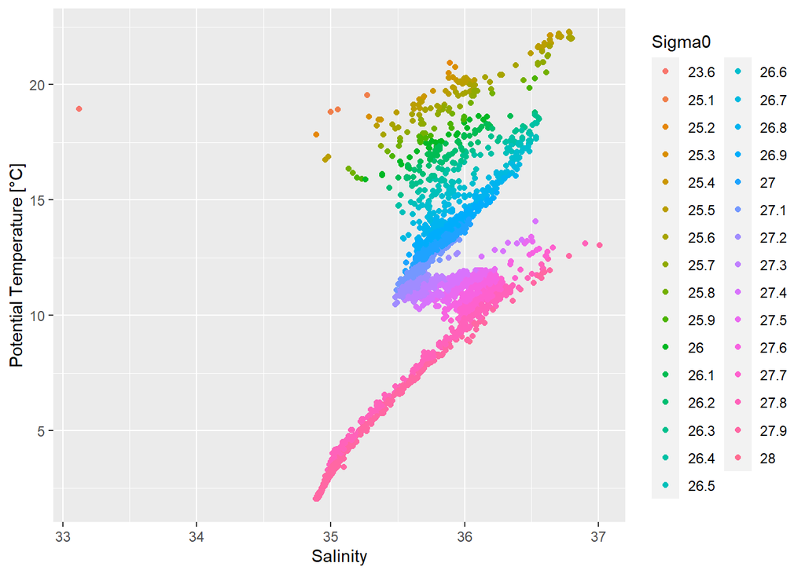

```r
  ggplot(A, aes(G2salinity, G2theta, color = as.character(round(G2sigma0, 1)))) +
    geom_point() +
    labs(color = "Sigma0") +
    xlab("Salinity") +
    ylab("Potential Temperature [°C]")
```

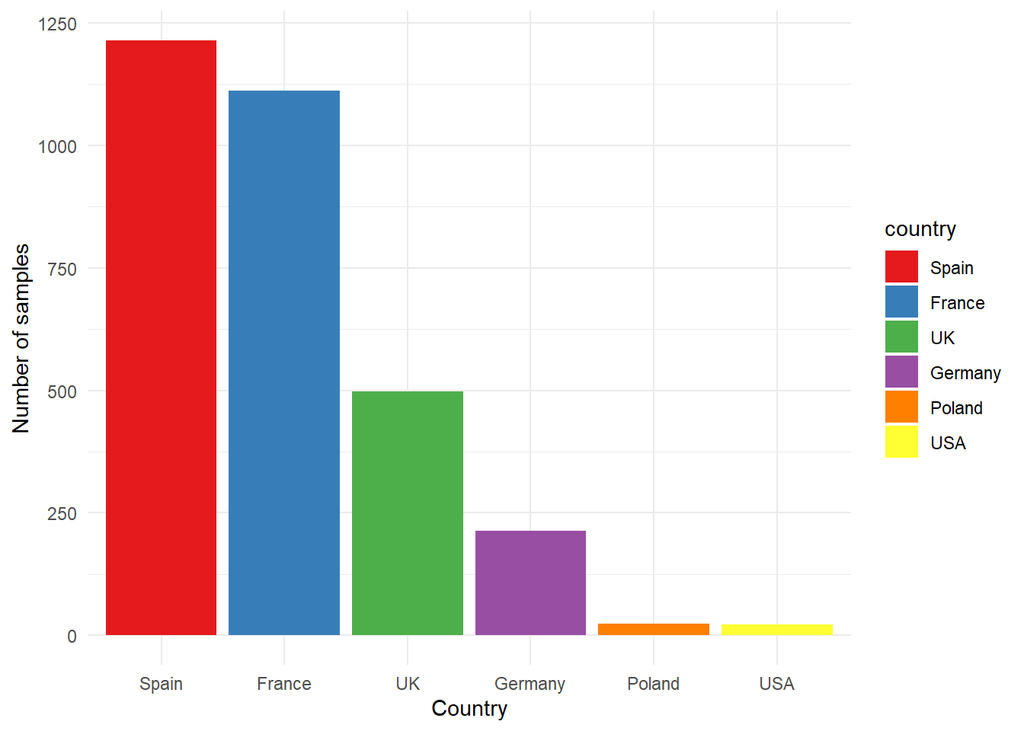

```r
  ggplot(A, aes(x = country)) +
    geom_bar(aes(fill = country)) +
    scale_fill_brewer(type = "qual", palette = "Set1") +
    labs(x = "Country", y = "Number of samples") +
    theme_minimal()
```

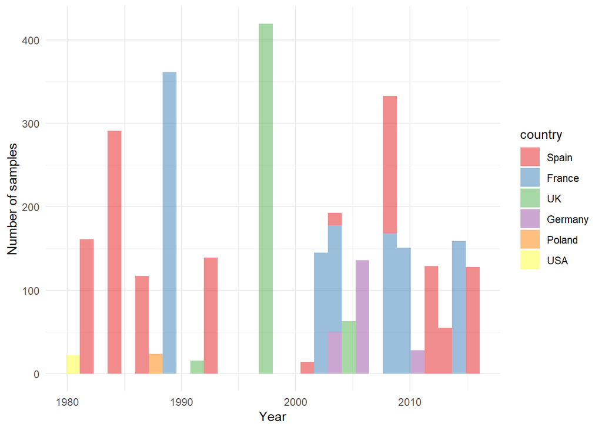

```r
  ggplot(A, aes(x = G2year)) +
    geom_histogram(aes(fill = country), alpha = .5) +
    scale_fill_brewer(type = "qual", palette = "Set1") +
    labs(x = "Year", y = "Number of samples") +
    theme_minimal()
```

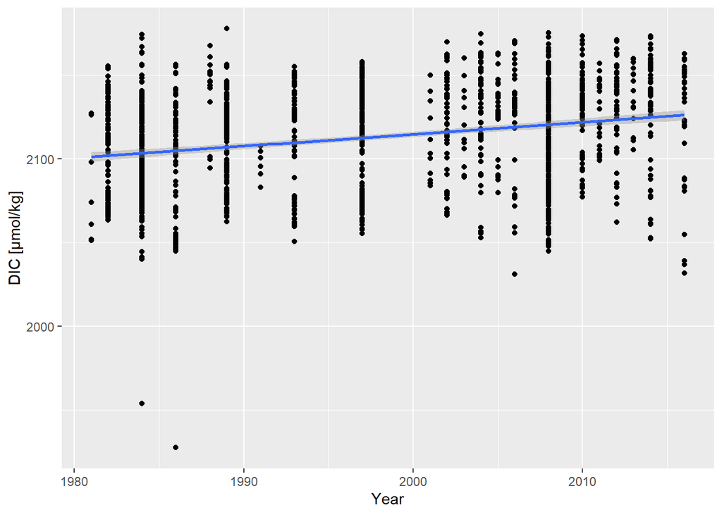

```r
  A %>%
    filter(G2depth < 500) %>%
    ggplot(., aes(G2year, DIC * 10^6)) +
    geom_point() +
    geom_smooth(method = "lm") +
    labs(x = "Year", y = "DIC [μmol/kg]")
```

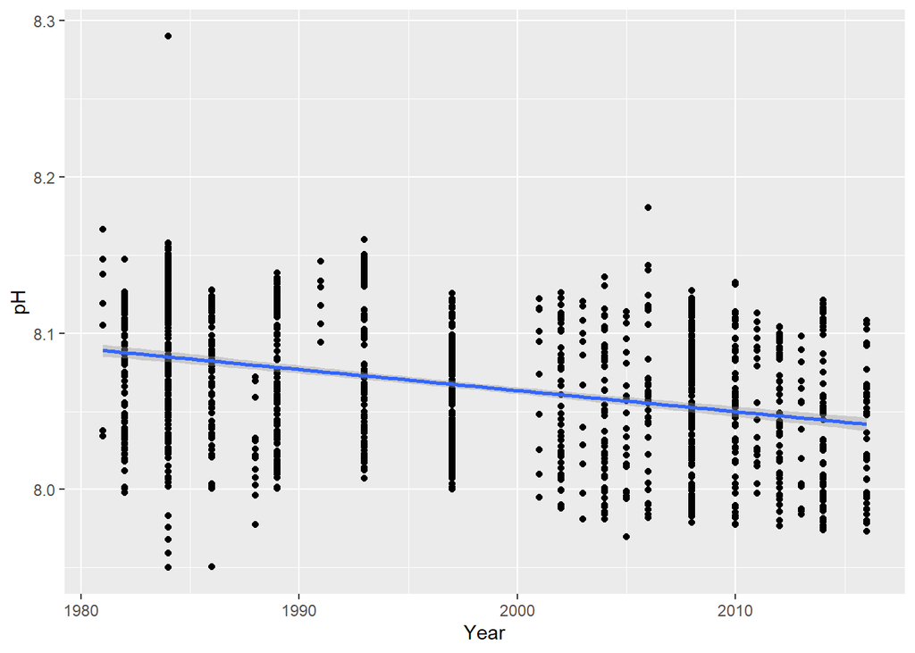

```r
  A %>%
    filter(G2depth < 500) %>%
    ggplot(., aes(G2year, pH)) +
    geom_point() +
    geom_smooth(method = "lm") +
    labs(x = "Year")
```

### Adding data from OldPT after application of neural networks

```r
postNN_OldPT <- read_csv("postNN_CO2sys_OldPT.csv", na = "NaN")

postNN_OldPT <- postNN_OldPT %>%
  mutate(source = "OldPT", country = "Portugal", xcCO3 = CO3out - (CO3out / OmegaARout)) %>%
  rename(G2year = year, pH = pHin)

postNN_OldPT$zone <- ifelse(postNN_OldPT$lat > 40.1, "zone1",
                            ifelse(postNN_OldPT$lat < 40.1 & postNN_OldPT$lat > 37.2, "zone2",
                              ifelse(postNN_OldPT$lat < 37.2, "zone3", NA)))
```

### Adding data from ICES after application of neural networks

```r
postNN_ICES <- read_csv("postNN_CO2sys_ICESfiltered.csv", na = "NaN")

postNN_ICES <- postNN_ICES %>%
  mutate(source = "ICES", country = "Portugal", xcCO3 = CO3out - (CO3out / OmegaARout)) %>%
  rename(G2year = year, pH = pHin)

postNN_ICES$zone <- ifelse(postNN_ICES$Latitudedegrees_north > 40.1, "zone1",
                           ifelse(postNN_ICES$Latitudedegrees_north < 40.1 & postNN_ICES$Latitudedegrees_north > 37.2, "zone2",
                              ifelse(postNN_ICES$Latitudedegrees_north < 37.2, "zone3", NA)))
```

```r
# # Checking for duplicate data (GLODAP & ICES): get distinct combinations of lat, lon & year, plot stations, and colour by source
# G2_check <- A %>% select(latitude = G2latitude, longitude = G2longitude, year = G2year, source) %>%
#   distinct(latitude, longitude, year, .keep_all = TRUE)
#
# ICES_check <- postNN_ICES %>% select(latitude = Latitudedegrees_north, longitude = Longitudedegrees_east, year, source) %>%
#   distinct(latitude, longitude, year, .keep_all = TRUE)
#
# check <- rbind(G2_check, ICES_check)
#
# ggplot(check, aes(longitude, latitude, colour = source)) +
#   geom_point(alpha = .7)
#
# check2 <- distinct(check, latitude, longitude, year, .keep_all = TRUE)  # Has the same number of rows as the check data frame, therefore no duplicate data
```

### Adding Iberia-Forams data

```r
# Iberia-Forams data
sheets <- excel_sheets("Iberia-Forams_pH_data.xlsx")
IF <- lapply(sheets, function(x) read_excel("Iberia-Forams_pH_data.xlsx", sheet = x))  # Reading all sheets
IF <- IF %>% rbind.fill()  # Combining all sheets in one data.frame

IF$pH_conv <- pHconv(flag = 2, pH = IF$`pH mean value`)  # Converting free scale to total scale (pH)

IF_add <- read.table("EUROFLEETS_Iberia-Forams_phys_oce.tab", header = TRUE, sep = "\t", fill = TRUE, row.names = NULL, encoding = "UTF-8")
```

### Adding Cant data

```r
Cant <- read.csv("Cant_source.csv")

Cant$source[Cant$source == "PT"] = "OldPT"
Cant$source[Cant$source == "G2"] = "GLODAP"
Cant$source[Cant$source == "IC"] = "ICES"

Cant$zone <- ifelse(Cant$latitude > 40.1, "zone1",
                           ifelse(Cant$latitude < 40.1 & Cant$latitude > 37.2, "zone2",
                              ifelse(Cant$latitude < 37.2, "zone3", NA)))
```

# PM trends step 2 - Trend analysis pH

### Preparing separate data.frames for the pH trend analysis

```r
# OldPT data
only_pH_OldPT <- postNN_OldPT %>%  # A new data.frame from the loaded csv (and we keep it intact as postNN*)
  filter(between(depth, 100, 500)) %>%  # To keep only the samples between 100 m and 500 m (both included)
  filter(pH > 7.9) %>%  # To delete some samples with very low pH (freshwater influence very likely)
  select(G2year, pH, source, zone)  # Clean it all

# ICES data (The same for the ICES data)
only_pH_ICES <- postNN_ICES %>%
  filter(between(PRESdb, 100, 500)) %>%  # To keep only the samples between 100 m and 500 m (both included)
  filter(pH > 7.9) %>%  # To delete some samples with very low pH (freshwater influence very likely)
  select(G2year, pH, source, zone)  # Clean it all

# Again for the GLODAP data
only_pH_G2 <- A %>%
  filter(between(G2depth, 100, 500)) %>%
  select(G2year, pH, epH, source, zone)

# Joining the three data.frames
pH_NN <- full_join(only_pH_OldPT, only_pH_ICES)
pH <- full_join(pH_NN, only_pH_G2)  # 2-step join
```

```r
# The idea was to put the repetitive code into a user defined function and apply it with lapply over the list of data.frames. Work in progress... solved it by copy pasting my code
#
# list <- list(pH, pH_NN, only_pH_G2)
#
# rlm_pH_fun <- function(data) {
#
# final_pH <- data %>%
#   group_by(G2year) %>%
#   summarise_at(vars(data), mean, na.rm = TRUE)
#
# final_pH_error <- data %>%
#   group_by(G2year) %>%
#   summarise_at(vars(data), sd, na.rm = TRUE)
#
# RLMmodel_pH <- MASS::rlm(pH ~ G2year, data = final_pH, weights = (1 / final_pH_error$pH))
# tableRLMmodel_pH <- summary(RLMmodel_pH)
# trend_pH <- tableRLMmodel_pH[["coefficients"]][2, 1]  # This is the rate of change
# etrend_pH <- tableRLMmodel_pH[["coefficients"]][2, 2]  # etrend stands for "error in the trend"
#
# pvalue_pH <- pnorm(
#   abs(
#     broom::tidy(RLMmodel_pH)
#     [2, "statistic", drop = TRUE]), lower.tail = FALSE) * 2
# }
#
# result <- lapply(purrr::map(list, "G2year", "pH"), rlm_pH_fun)  # map is used to select the columns G2year and pH of all elements in the list
```

### Computing mean pH and error of the mean

```r
# All zones
# Computing the mean pH and error of the mean per year for the whole data set (GLODAP + OldPT + ICES)
final_pH <- pH %>%
  group_by(G2year) %>%
  summarise_at(vars(pH), mean, na.rm = TRUE)

final_pH_error <- pH %>%
  group_by(G2year) %>%
  summarise_at(vars(pH), sd, na.rm = TRUE)

# Computing the mean pH and error of the mean per year for the NN data set (OldPT + ICES)
final_pH_NN <- pH_NN %>%
  group_by(G2year) %>%
  summarise_at(vars(pH), mean, na.rm = TRUE)

final_pH_error_NN <- pH_NN %>%
  group_by(G2year) %>%
  summarise_at(vars(pH), sd, na.rm = TRUE)

# Computing the mean pH and error of the mean per year for the GLODAP data set
final_pH_G2 <- only_pH_G2 %>%
  group_by(G2year) %>%
  summarise_at(vars(pH), mean, na.rm = TRUE)

final_pH_error_G2 <- only_pH_G2 %>%
  group_by(G2year) %>%
  summarise_at(vars(pH), sd, na.rm = TRUE)

# Zone 1
# Computing the mean pH and error of the mean per year for the whole data set (GLODAP + OldPT + ICES)
final_pH_1 <- pH %>%
  subset(zone == "zone1") %>%
  group_by(G2year) %>%
  summarise_at(vars(pH), mean, na.rm = TRUE)

final_pH_error_1 <- pH %>%
  subset(zone == "zone1") %>%
  group_by(G2year) %>%
  summarise_at(vars(pH), sd, na.rm = TRUE)

# Computing the mean pH and error of the mean per year for the NN data set (OldPT + ICES)
final_pH_NN_1 <- pH_NN %>%
  subset(zone == "zone1") %>%
  group_by(G2year) %>%
  summarise_at(vars(pH), mean, na.rm = TRUE)

final_pH_error_NN_1 <- pH_NN %>%
  subset(zone == "zone1") %>%
  group_by(G2year) %>%
  summarise_at(vars(pH), sd, na.rm = TRUE)

# Computing the mean pH and error of the mean per year for the GLODAP data set
final_pH_G2_1 <- only_pH_G2 %>%
  subset(zone == "zone1") %>%
  group_by(G2year) %>%
  summarise_at(vars(pH), mean, na.rm = TRUE)

final_pH_error_G2_1 <- only_pH_G2 %>%
  subset(zone == "zone1") %>%
  group_by(G2year) %>%
  summarise_at(vars(pH), sd, na.rm = TRUE)

# Zone 2
# Computing the mean pH and error of the mean per year for the whole data set (GLODAP + OldPT + ICES)
final_pH_2 <- pH %>%
  subset(zone == "zone2") %>%
  group_by(G2year) %>%
  summarise_at(vars(pH), mean, na.rm = TRUE)

final_pH_error_2 <- pH %>%
  subset(zone == "zone2") %>%
  group_by(G2year) %>%
  summarise_at(vars(pH), sd, na.rm = TRUE)

# Computing the mean pH and error of the mean per year for the NN data set (OldPT + ICES)
final_pH_NN_2 <- pH_NN %>%
  subset(zone == "zone2") %>%
  group_by(G2year) %>%
  summarise_at(vars(pH), mean, na.rm = TRUE)

final_pH_error_NN_2 <- pH_NN %>%
  subset(zone == "zone2") %>%
  group_by(G2year) %>%
  summarise_at(vars(pH), sd, na.rm = TRUE)

# Computing the mean pH and error of the mean per year for the GLODAP data set
final_pH_G2_2 <- only_pH_G2 %>%
  subset(zone == "zone2") %>%
  group_by(G2year) %>%
  summarise_at(vars(pH), mean, na.rm = TRUE)

final_pH_error_G2_2 <- only_pH_G2 %>%
  subset(zone == "zone2") %>%
  group_by(G2year) %>%
  summarise_at(vars(pH), sd, na.rm = TRUE)

# Zone 3
# Computing the mean pH and error of the mean per year for the whole data set (GLODAP + OldPT + ICES)
final_pH_3 <- pH %>%
  subset(zone == "zone3") %>%
  group_by(G2year) %>%
  summarise_at(vars(pH), mean, na.rm = TRUE)

final_pH_error_3 <- pH %>%
  subset(zone == "zone3") %>%
  group_by(G2year) %>%
  summarise_at(vars(pH), sd, na.rm = TRUE)

# Computing the mean pH and error of the mean per year for the NN data set (OldPT + ICES)
final_pH_NN_3 <- pH_NN %>%
  subset(zone == "zone3") %>%
  group_by(G2year) %>%
  summarise_at(vars(pH), mean, na.rm = TRUE)

final_pH_error_NN_3 <- pH_NN %>%
  subset(zone == "zone3") %>%
  group_by(G2year) %>%
  summarise_at(vars(pH), sd, na.rm = TRUE)

# Computing the mean pH and error of the mean per year for the GLODAP data set
final_pH_G2_3 <- only_pH_G2 %>%
  subset(zone == "zone3") %>%
  group_by(G2year) %>%
  summarise_at(vars(pH), mean, na.rm = TRUE)

final_pH_error_G2_3 <- only_pH_G2 %>%
  subset(zone == "zone3") %>%
  group_by(G2year) %>%
  summarise_at(vars(pH), sd, na.rm = TRUE)
```

### Robust linear model for pH

```r
# All zones
# Linear model for the complete data set (GLODAP + OldPT + ICES)
RLMmodel_pH <- MASS::rlm(pH ~ G2year, data = final_pH, weights = (1 / final_pH_error$pH))

tableRLMmodel_pH <- summary(RLMmodel_pH)
trend_pH <- tableRLMmodel_pH[["coefficients"]][2, 1]  # This is the rate of change
etrend_pH <- tableRLMmodel_pH[["coefficients"]][2, 2]  # etrend stands for "error in the trend"

pvalue_pH <- pnorm(
  abs(
    broom::tidy(RLMmodel_pH)
    [2, "statistic", drop = TRUE]), lower.tail = FALSE) * 2

# Linear model for the NN data set (OldPT + ICES)
RLMmodel_pH_NN <- MASS::rlm(pH ~ G2year, data = final_pH_NN, weights = (1 / final_pH_error_NN$pH))

tableRLMmodel_pH_NN <- summary(RLMmodel_pH_NN)
trend_pH_NN <- tableRLMmodel_pH_NN[["coefficients"]][2, 1]  # This is the rate of change
etrend_pH_NN <- tableRLMmodel_pH_NN[["coefficients"]][2, 2]  # etrend stands for "error in the trend"

pvalue_pH_NN <- pnorm(
  abs(
    broom::tidy(RLMmodel_pH_NN)
    [2, "statistic", drop = TRUE]), lower.tail = FALSE) * 2

# Linear model for the GLODAP data set
RLMmodel_pH_G2 <- MASS::rlm(pH ~ G2year, data = final_pH_G2, weights = (1 / final_pH_error_G2$pH))

tableRLMmodel_pH_G2 <- summary(RLMmodel_pH_G2)
trend_pH_G2 <- tableRLMmodel_pH_G2[["coefficients"]][2, 1]  # This is the rate of change
etrend_pH_G2 <- tableRLMmodel_pH_G2[["coefficients"]][2, 2]  # etrend stands for "error in the trend"

pvalue_pH_G2 <- pnorm(
  abs(
    broom::tidy(RLMmodel_pH_G2)
    [2, "statistic", drop = TRUE]), lower.tail = FALSE) * 2

# Zone 1
# Linear model for the complete data set (GLODAP + OldPT + ICES)
RLMmodel_pH_1 <- MASS::rlm(pH ~ G2year, data = final_pH_1, weights = (1 / final_pH_error_1$pH))

tableRLMmodel_pH_1 <- summary(RLMmodel_pH_1)
trend_pH_1 <- tableRLMmodel_pH_1[["coefficients"]][2, 1]  # This is the rate of change
etrend_pH_1 <- tableRLMmodel_pH_1[["coefficients"]][2, 2]  # etrend stands for "error in the trend"

pvalue_pH_1 <- pnorm(
  abs(
    broom::tidy(RLMmodel_pH_1)
    [2, "statistic", drop = TRUE]), lower.tail = FALSE) * 2

# Linear model for the NN data set (OldPT + ICES)
RLMmodel_pH_NN_1 <- MASS::rlm(pH ~ G2year, data = final_pH_NN_1, weights = (1 / final_pH_error_NN_1$pH))

tableRLMmodel_pH_NN_1 <- summary(RLMmodel_pH_NN_1)
trend_pH_NN_1 <- tableRLMmodel_pH_NN_1[["coefficients"]][2, 1]  # This is the rate of change
etrend_pH_NN_1 <- tableRLMmodel_pH_NN_1[["coefficients"]][2, 2]  # etrend stands for "error in the trend"

pvalue_pH_NN_1 <- pnorm(
  abs(
    broom::tidy(RLMmodel_pH_NN_1)
    [2, "statistic", drop = TRUE]), lower.tail = FALSE) * 2

# Linear model for the GLODAP data set
RLMmodel_pH_G2_1 <- MASS::rlm(pH ~ G2year, data = final_pH_G2_1, weights = (1 / final_pH_error_G2_1$pH))

tableRLMmodel_pH_G2_1 <- summary(RLMmodel_pH_G2_1)
trend_pH_G2_1 <- tableRLMmodel_pH_G2_1[["coefficients"]][2, 1]  # This is the rate of change
etrend_pH_G2_1 <- tableRLMmodel_pH_G2_1[["coefficients"]][2, 2]  # etrend stands for "error in the trend"

pvalue_pH_G2_1 <- pnorm(
  abs(
    broom::tidy(RLMmodel_pH_G2_1)
    [2, "statistic", drop = TRUE]), lower.tail = FALSE) * 2

# Zone 2
# Linear model for the complete data set (GLODAP + OldPT + ICES)
RLMmodel_pH_2 <- MASS::rlm(pH ~ G2year, data = final_pH_2, weights = (1 / final_pH_error_2$pH))

tableRLMmodel_pH_2 <- summary(RLMmodel_pH_2)
trend_pH_2 <- tableRLMmodel_pH_2[["coefficients"]][2, 1]  # This is the rate of change
etrend_pH_2 <- tableRLMmodel_pH_2[["coefficients"]][2, 2]  # etrend stands for "error in the trend"

pvalue_pH_2 <- pnorm(
  abs(
    broom::tidy(RLMmodel_pH_2)
    [2, "statistic", drop = TRUE]), lower.tail = FALSE) * 2

# Linear model for the NN data set (OldPT + ICES)
RLMmodel_pH_NN_2 <- MASS::rlm(pH ~ G2year, data = final_pH_NN_2, weights = (1 / final_pH_error_NN_2$pH))

tableRLMmodel_pH_NN_2 <- summary(RLMmodel_pH_NN_2)
trend_pH_NN_2 <- tableRLMmodel_pH_NN_2[["coefficients"]][2, 1]  # This is the rate of change
etrend_pH_NN_2 <- tableRLMmodel_pH_NN_2[["coefficients"]][2, 2]  # etrend stands for "error in the trend"

pvalue_pH_NN_2 <- pnorm(
  abs(
    broom::tidy(RLMmodel_pH_NN_2)
    [2, "statistic", drop = TRUE]), lower.tail = FALSE) * 2

# Linear model for the GLODAP data set
RLMmodel_pH_G2_2 <- MASS::rlm(pH ~ G2year, data = final_pH_G2_2, weights = (1 / final_pH_error_G2_2$pH))

tableRLMmodel_pH_G2_2 <- summary(RLMmodel_pH_G2_2)
trend_pH_G2_2 <- tableRLMmodel_pH_G2_2[["coefficients"]][2, 1]  # This is the rate of change
etrend_pH_G2_2 <- tableRLMmodel_pH_G2_2[["coefficients"]][2, 2]  # etrend stands for "error in the trend"

pvalue_pH_G2_2 <- pnorm(
  abs(
    broom::tidy(RLMmodel_pH_G2_2)
    [2, "statistic", drop = TRUE]), lower.tail = FALSE) * 2

# Zone 3
# Linear model for the complete data set (GLODAP + OldPT + ICES)
RLMmodel_pH_3 <- MASS::rlm(pH ~ G2year, data = final_pH_3, weights = (1 / final_pH_error_3$pH))

tableRLMmodel_pH_3 <- summary(RLMmodel_pH_3)
trend_pH_3 <- tableRLMmodel_pH_3[["coefficients"]][2, 1]  # This is the rate of change
etrend_pH_3 <- tableRLMmodel_pH_3[["coefficients"]][2, 2]  # etrend stands for "error in the trend"

pvalue_pH_3 <- pnorm(
  abs(
    broom::tidy(RLMmodel_pH_3)
    [2, "statistic", drop = TRUE]), lower.tail = FALSE) * 2

# Linear model for the NN data set (OldPT + ICES)
RLMmodel_pH_NN_3 <- MASS::rlm(pH ~ G2year, data = final_pH_NN_3, weights = (1 / final_pH_error_NN_3$pH))

tableRLMmodel_pH_NN_3 <- summary(RLMmodel_pH_NN_3)
trend_pH_NN_3 <- tableRLMmodel_pH_NN_3[["coefficients"]][2, 1]  # This is the rate of change
etrend_pH_NN_3 <- tableRLMmodel_pH_NN_3[["coefficients"]][2, 2]  # etrend stands for "error in the trend"

pvalue_pH_NN_3 <- pnorm(
  abs(
    broom::tidy(RLMmodel_pH_NN_3)
    [2, "statistic", drop = TRUE]), lower.tail = FALSE) * 2

# Linear model for the GLODAP data set
RLMmodel_pH_G2_3 <- MASS::rlm(pH ~ G2year, data = final_pH_G2_3, weights = (1 / final_pH_error_G2_3$pH))

tableRLMmodel_pH_G2_3 <- summary(RLMmodel_pH_G2_3)
trend_pH_G2_3 <- tableRLMmodel_pH_G2_3[["coefficients"]][2, 1]  # This is the rate of change
etrend_pH_G2_3 <- tableRLMmodel_pH_G2_3[["coefficients"]][2, 2]  # etrend stands for "error in the trend"

pvalue_pH_G2_3 <- pnorm(
  abs(
    broom::tidy(RLMmodel_pH_G2_3)
    [2, "statistic", drop = TRUE]), lower.tail = FALSE) * 2
```

Method: The data-set used for the pH analysis consists of the combined data taken from GLODAP, ICES, as well as the “rescued” data from the old cruises in the Portuguese Margin. pH is represented on the total scale and at in situ temperature and pressure. Very low pH-values below 7.9 were excluded, since freshwater influence is very likely in those cases. As before, only data points below 100 m, in order to avoid seasonal variation, and above 500 m, due to sample constraint in the OldPT data set, were included in the study. Mean pH and standard deviation per year were computed for the complete data set (GLODAP, ICES, and OldPT), GLODAP data alone, and for the modelled data (ICES and OldPT). Using these means and standard deviations, we applied a robust linear model, with the “rlm” function from the R package “MASS”, to compute the pH trends, as well as the error of the trends. The associated p-values were computed with the “pnorm” function.

### Plot showing the pH trend

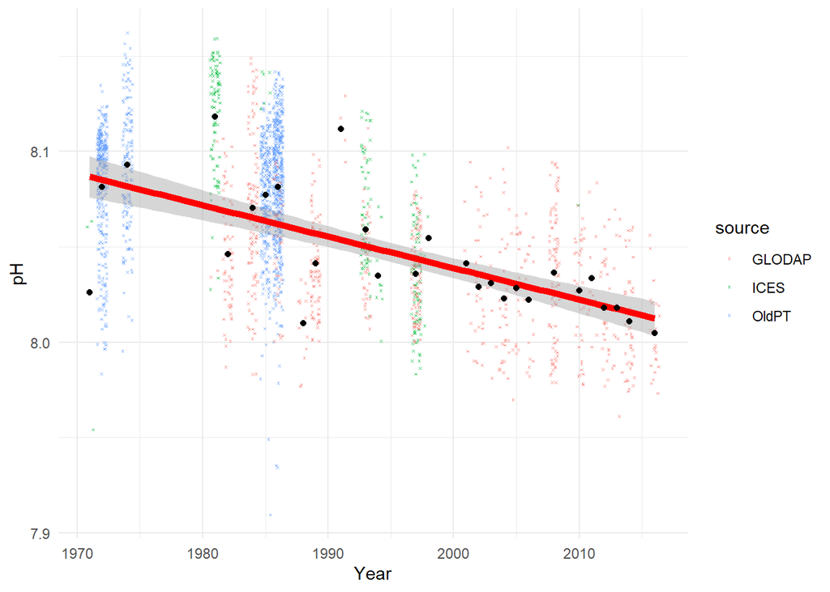

```r
ggplot(final_pH, aes(G2year, pH)) +
  geom_jitter(data = pH, aes(colour = source), alpha = .7, shape = 4, size = .3) +
  geom_smooth(method = MASS::rlm, color = "red", size = 2) +
  geom_point() +
  theme_minimal() +
  xlab("Year")
```

Result: Figure 3 shows the pH trend between 1971 and 2016 in subsurface waters (100 m - 500 m) of the Portuguese Margin. The measurements are coloured according to their source, GLODAP in red, ICES in green, and old cruise data in blue. The black points represent the means of each year. [Should I add the min and max value of the trend? If yes, how can I find them?] The pH value decreased steadily at a rate of -0.0017 ± 0.0002 per year. The associated p-value is < 0.05. Through adding the pH values from the “rescued” old cruise data, we were able to fill knowledge gaps and increase the time frame of the linear model by about one decade. Using only the data from GLODAP, a negative trend of -0.0012 ± 0.0002 was computed (p-value < 0.05). For the modelled data the trend was -0.0017 ± 0.0009 with a p-value < 0.05.

# PM trends step 3 - Trend analysis anthropogenic carbon

### Preparing a separate data.frame for the Cant trend analysis

```r
only_Cant <- Cant %>%
  filter(latitude >= (min(ABasin$lat)) & latitude <= (max(ABasin$lat))) %>%
  filter(longitude >= (min(ABasin$lon)) & longitude <= (max(ABasin$lon))) %>%
  mutate_all(.funs = funs(ifelse(. == "NaN", NA, .))) %>%
  filter(between(Depth, 100, 500)) %>%
  filter(!is.na(cAntPhiCt0ML)) %>%
  select(year, cAntPhiCt0ML, source, zone)
```

### Computing mean Cant per year and error of the mean

```r
# All zones
# complete data set
final_Cant <- only_Cant %>%
  group_by(year) %>%
  summarise_at(vars(cAntPhiCt0ML), mean, na.rm = TRUE)

final_Cant_error <- only_Cant %>%
  group_by(year) %>%
  summarise_at(vars(cAntPhiCt0ML), sd, na.rm = TRUE)

# Neural network data
final_Cant_NN <- only_Cant %>%
  filter(source == "OldPT" | source == "ICES") %>%
  group_by(year) %>%
  summarise_at(vars(cAntPhiCt0ML), mean, na.rm = TRUE)

final_Cant_error_NN <- only_Cant %>%
  filter(source == "OldPT" | source == "ICES") %>%
  group_by(year) %>%
  summarise_at(vars(cAntPhiCt0ML), sd, na.rm = TRUE)

# GLODAP data
final_Cant_G2 <- only_Cant %>%
  filter(source == "GLODAP") %>%
  group_by(year) %>%
  summarise_at(vars(cAntPhiCt0ML), mean, na.rm = TRUE)

final_Cant_error_G2 <- only_Cant %>%
  filter(source == "GLODAP") %>%
  group_by(year) %>%
  summarise_at(vars(cAntPhiCt0ML), sd, na.rm = TRUE)

# Zone 1
# complete data set
final_Cant_1 <- only_Cant %>%
  subset(zone == "zone1") %>%
  group_by(year) %>%
  summarise_at(vars(cAntPhiCt0ML), mean, na.rm = TRUE)

final_Cant_error_1 <- only_Cant %>%
  subset(zone == "zone1") %>%
  group_by(year) %>%
  summarise_at(vars(cAntPhiCt0ML), sd, na.rm = TRUE)

# Neural network data
final_Cant_NN_1 <- only_Cant %>%
  subset(zone == "zone1") %>%
  filter(source == "OldPT" | source == "ICES") %>%
  group_by(year) %>%
  summarise_at(vars(cAntPhiCt0ML), mean, na.rm = TRUE)

final_Cant_error_NN_1 <- only_Cant %>%
  subset(zone == "zone1") %>%
  filter(source == "OldPT" | source == "ICES") %>%
  group_by(year) %>%
  summarise_at(vars(cAntPhiCt0ML), sd, na.rm = TRUE)

# GLODAP data
final_Cant_G2_1 <- only_Cant %>%
  subset(zone == "zone1") %>%
  filter(source == "GLODAP") %>%
  group_by(year) %>%
  summarise_at(vars(cAntPhiCt0ML), mean, na.rm = TRUE)

final_Cant_error_G2_1 <- only_Cant %>%
  subset(zone == "zone1") %>%
  filter(source == "GLODAP") %>%
  group_by(year) %>%
  summarise_at(vars(cAntPhiCt0ML), sd, na.rm = TRUE)

# Zone 2
# complete data set
final_Cant_2 <- only_Cant %>%
  subset(zone == "zone2") %>%
  group_by(year) %>%
  summarise_at(vars(cAntPhiCt0ML), mean, na.rm = TRUE)

final_Cant_error_2 <- only_Cant %>%
  subset(zone == "zone2") %>%
  group_by(year) %>%
  summarise_at(vars(cAntPhiCt0ML), sd, na.rm = TRUE)

# Neural network data
final_Cant_NN_2 <- only_Cant %>%
  subset(zone == "zone2") %>%
  filter(source == "OldPT" | source == "ICES") %>%
  group_by(year) %>%
  summarise_at(vars(cAntPhiCt0ML), mean, na.rm = TRUE)

final_Cant_error_NN_2 <- only_Cant %>%
  subset(zone == "zone2") %>%
  filter(source == "OldPT" | source == "ICES") %>%
  group_by(year) %>%
  summarise_at(vars(cAntPhiCt0ML), sd, na.rm = TRUE)

# GLODAP data
final_Cant_G2_2 <- only_Cant %>%
  subset(zone == "zone2") %>%
  filter(source == "GLODAP") %>%
  group_by(year) %>%
  summarise_at(vars(cAntPhiCt0ML), mean, na.rm = TRUE)

final_Cant_error_G2_2 <- only_Cant %>%
  subset(zone == "zone2") %>%
  filter(source == "GLODAP") %>%
  group_by(year) %>%
  summarise_at(vars(cAntPhiCt0ML), sd, na.rm = TRUE)

# Zone 3
# complete data set
final_Cant_3 <- only_Cant %>%
  subset(zone == "zone3") %>%
  group_by(year) %>%
  summarise_at(vars(cAntPhiCt0ML), mean, na.rm = TRUE)

final_Cant_error_3 <- only_Cant %>%
  subset(zone == "zone3") %>%
  group_by(year) %>%
  summarise_at(vars(cAntPhiCt0ML), sd, na.rm = TRUE)

# Neural network data
final_Cant_NN_3 <- only_Cant %>%
  subset(zone == "zone3") %>%
  filter(source == "OldPT" | source == "ICES") %>%
  group_by(year) %>%
  summarise_at(vars(cAntPhiCt0ML), mean, na.rm = TRUE)

final_Cant_error_NN_3 <- only_Cant %>%
  subset(zone == "zone3") %>%
  filter(source == "OldPT" | source == "ICES") %>%
  group_by(year) %>%
  summarise_at(vars(cAntPhiCt0ML), sd, na.rm = TRUE)

# GLODAP data
final_Cant_G2_3 <- only_Cant %>%
  subset(zone == "zone3") %>%
  filter(source == "GLODAP") %>%
  group_by(year) %>%
  summarise_at(vars(cAntPhiCt0ML), mean, na.rm = TRUE)

final_Cant_error_G2_3 <- only_Cant %>%
  subset(zone == "zone3") %>%
  filter(source == "GLODAP") %>%
  group_by(year) %>%
  summarise_at(vars(cAntPhiCt0ML), sd, na.rm = TRUE)
```

### Robust linear model for Cant

```r
# All zones
# Complete data set
RLMmodel_Cant <- MASS::rlm(cAntPhiCt0ML ~ year, data = final_Cant, weights = (1 / final_Cant_error$cAntPhiCt0ML))

tableRLMmodel_Cant <- summary(RLMmodel_Cant)
trend_Cant <- tableRLMmodel_Cant[["coefficients"]][2, 1]  # This is the rate of change
etrend_Cant <- tableRLMmodel_Cant[["coefficients"]][2, 2]  # etrend stands for "error in the trend"

pvalue_Cant <- pnorm(
  abs(
    broom::tidy(RLMmodel_Cant)
    [2, "statistic", drop = TRUE]), lower.tail = FALSE) * 2

# Neural network data
RLMmodel_Cant_NN <- MASS::rlm(cAntPhiCt0ML ~ year, data = final_Cant_NN, weights = (1 / final_Cant_error_NN$cAntPhiCt0ML))

tableRLMmodel_Cant_NN <- summary(RLMmodel_Cant_NN)
trend_Cant_NN <- tableRLMmodel_Cant_NN[["coefficients"]][2, 1]  # This is the rate of change
etrend_Cant_NN <- tableRLMmodel_Cant_NN[["coefficients"]][2, 2]  # etrend stands for "error in the trend"

pvalue_Cant_NN <- pnorm(
  abs(
    broom::tidy(RLMmodel_Cant_NN)
    [2, "statistic", drop = TRUE]), lower.tail = FALSE) * 2

# GLODAP data
RLMmodel_Cant_G2 <- MASS::rlm(cAntPhiCt0ML ~ year, data = final_Cant_G2, weights = (1 / final_Cant_error_G2$cAntPhiCt0ML))

tableRLMmodel_Cant_G2 <- summary(RLMmodel_Cant_G2)
trend_Cant_G2 <- tableRLMmodel_Cant_G2[["coefficients"]][2, 1]  # This is the rate of change
etrend_Cant_G2 <- tableRLMmodel_Cant_G2[["coefficients"]][2, 2]  # etrend stands for "error in the trend"

pvalue_Cant_G2 <- pnorm(
  abs(
    broom::tidy(RLMmodel_Cant_G2)
    [2, "statistic", drop = TRUE]), lower.tail = FALSE) * 2

# Zone 1
# Complete data set
RLMmodel_Cant_1 <- MASS::rlm(cAntPhiCt0ML ~ year, data = final_Cant_1, weights = (1 / final_Cant_error_1$cAntPhiCt0ML))

tableRLMmodel_Cant_1 <- summary(RLMmodel_Cant_1)
trend_Cant_1 <- tableRLMmodel_Cant_1[["coefficients"]][2, 1]  # This is the rate of change
etrend_Cant_1 <- tableRLMmodel_Cant_1[["coefficients"]][2, 2]  # etrend stands for "error in the trend"

pvalue_Cant_1 <- pnorm(
  abs(
    broom::tidy(RLMmodel_Cant_1)
    [2, "statistic", drop = TRUE]), lower.tail = FALSE) * 2

# Neural network data
RLMmodel_Cant_NN_1 <- MASS::rlm(cAntPhiCt0ML ~ year, data = final_Cant_NN_1, weights = (1 / final_Cant_error_NN_1$cAntPhiCt0ML))

tableRLMmodel_Cant_NN_1 <- summary(RLMmodel_Cant_NN_1)
trend_Cant_NN_1 <- tableRLMmodel_Cant_NN_1[["coefficients"]][2, 1]  # This is the rate of change
etrend_Cant_NN_1 <- tableRLMmodel_Cant_NN_1[["coefficients"]][2, 2]  # etrend stands for "error in the trend"

pvalue_Cant_NN_1 <- pnorm(
  abs(
    broom::tidy(RLMmodel_Cant_NN_1)
    [2, "statistic", drop = TRUE]), lower.tail = FALSE) * 2

# GLODAP data
RLMmodel_Cant_G2_1 <- MASS::rlm(cAntPhiCt0ML ~ year, data = final_Cant_G2_1, weights = (1 / final_Cant_error_G2_1$cAntPhiCt0ML))

tableRLMmodel_Cant_G2_1 <- summary(RLMmodel_Cant_G2_1)
trend_Cant_G2_1 <- tableRLMmodel_Cant_G2_1[["coefficients"]][2, 1]  # This is the rate of change
etrend_Cant_G2_1 <- tableRLMmodel_Cant_G2_1[["coefficients"]][2, 2]  # etrend stands for "error in the trend"

pvalue_Cant_G2_1 <- pnorm(
  abs(
    broom::tidy(RLMmodel_Cant_G2_1)
    [2, "statistic", drop = TRUE]), lower.tail = FALSE) * 2

# Zone 2
# Complete data set
RLMmodel_Cant_2 <- MASS::rlm(cAntPhiCt0ML ~ year, data = final_Cant_2, weights = (1 / final_Cant_error_2$cAntPhiCt0ML))

tableRLMmodel_Cant_2 <- summary(RLMmodel_Cant_2)
trend_Cant_2 <- tableRLMmodel_Cant_2[["coefficients"]][2, 1]  # This is the rate of change
etrend_Cant_2 <- tableRLMmodel_Cant_2[["coefficients"]][2, 2]  # etrend stands for "error in the trend"

pvalue_Cant_2 <- pnorm(
  abs(
    broom::tidy(RLMmodel_Cant_2)
    [2, "statistic", drop = TRUE]), lower.tail = FALSE) * 2

# Neural network data
RLMmodel_Cant_NN_2 <- MASS::rlm(cAntPhiCt0ML ~ year, data = final_Cant_NN_2, weights = (1 / final_Cant_error_NN_2$cAntPhiCt0ML))

tableRLMmodel_Cant_NN_2 <- summary(RLMmodel_Cant_NN_2)
trend_Cant_NN_2 <- tableRLMmodel_Cant_NN_2[["coefficients"]][2, 1]  # This is the rate of change
etrend_Cant_NN_2 <- tableRLMmodel_Cant_NN_2[["coefficients"]][2, 2]  # etrend stands for "error in the trend"

pvalue_Cant_NN_2 <- pnorm(
  abs(
    broom::tidy(RLMmodel_Cant_NN_2)
    [2, "statistic", drop = TRUE]), lower.tail = FALSE) * 2

# GLODAP data
RLMmodel_Cant_G2_2 <- MASS::rlm(cAntPhiCt0ML ~ year, data = final_Cant_G2_2, weights = (1 / final_Cant_error_G2_2$cAntPhiCt0ML))

tableRLMmodel_Cant_G2_2 <- summary(RLMmodel_Cant_G2_2)
trend_Cant_G2_2 <- tableRLMmodel_Cant_G2_2[["coefficients"]][2, 1]  # This is the rate of change
etrend_Cant_G2_2 <- tableRLMmodel_Cant_G2_2[["coefficients"]][2, 2]  # etrend stands for "error in the trend"

pvalue_Cant_G2_2 <- pnorm(
  abs(
    broom::tidy(RLMmodel_Cant_G2_2)
    [2, "statistic", drop = TRUE]), lower.tail = FALSE) * 2

# Zone 3
# Complete data set
RLMmodel_Cant_3 <- MASS::rlm(cAntPhiCt0ML ~ year, data = final_Cant_3, weights = (1 / final_Cant_error_3$cAntPhiCt0ML))

tableRLMmodel_Cant_3 <- summary(RLMmodel_Cant_3)
trend_Cant_3 <- tableRLMmodel_Cant_3[["coefficients"]][2, 1]  # This is the rate of change
etrend_Cant_3 <- tableRLMmodel_Cant_3[["coefficients"]][2, 2]  # etrend stands for "error in the trend"

pvalue_Cant_3 <- pnorm(
  abs(
    broom::tidy(RLMmodel_Cant_3)
    [2, "statistic", drop = TRUE]), lower.tail = FALSE) * 2

# Neural network data
RLMmodel_Cant_NN_3 <- MASS::rlm(cAntPhiCt0ML ~ year, data = final_Cant_NN_3, weights = (1 / final_Cant_error_NN_3$cAntPhiCt0ML))

tableRLMmodel_Cant_NN_3 <- summary(RLMmodel_Cant_NN_3)
trend_Cant_NN_3 <- tableRLMmodel_Cant_NN_3[["coefficients"]][2, 1]  # This is the rate of change
etrend_Cant_NN_3 <- tableRLMmodel_Cant_NN_3[["coefficients"]][2, 2]  # etrend stands for "error in the trend"

pvalue_Cant_NN_3 <- pnorm(
  abs(
    broom::tidy(RLMmodel_Cant_NN_3)
    [2, "statistic", drop = TRUE]), lower.tail = FALSE) * 2

# GLODAP data
RLMmodel_Cant_G2_3 <- MASS::rlm(cAntPhiCt0ML ~ year, data = final_Cant_G2_3, weights = (1 / final_Cant_error_G2_3$cAntPhiCt0ML))

tableRLMmodel_Cant_G2_3 <- summary(RLMmodel_Cant_G2_3)
trend_Cant_G2_3 <- tableRLMmodel_Cant_G2_3[["coefficients"]][2, 1]  # This is the rate of change
etrend_Cant_G2_3 <- tableRLMmodel_Cant_G2_3[["coefficients"]][2, 2]  # etrend stands for "error in the trend"

pvalue_Cant_G2_3 <- pnorm(
  abs(
    broom::tidy(RLMmodel_Cant_G2_3)
    [2, "statistic", drop = TRUE]), lower.tail = FALSE) * 2
```

### Plot showing the Cant trend

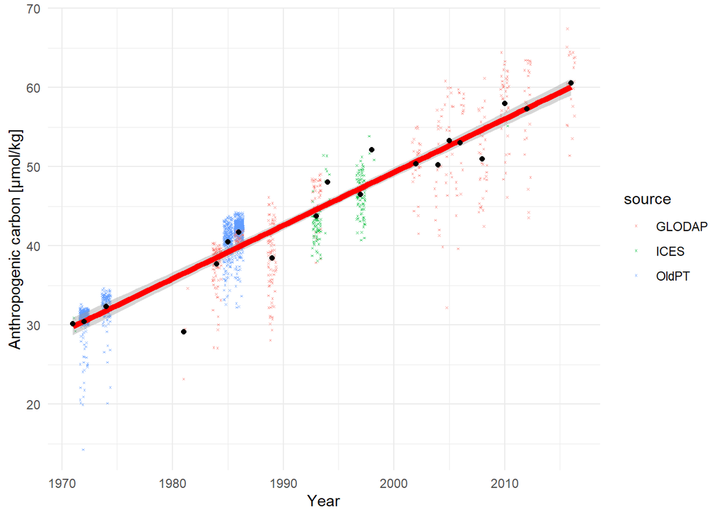

```r
ggplot(final_Cant, aes(year, cAntPhiCt0ML)) +
  geom_jitter(data = only_Cant, aes(colour = source), alpha = .7, shape = 4, size = .3) +
  geom_smooth(method = MASS::rlm, color = "red", size = 2) +
  geom_point() +
  theme_minimal() +
  xlab("Year") +
  ylab("Anthropogenic carbon [μmol/kg]")
```

# PM trends step 4 - Trend analysis xcCO3

### Preparing separate data.frames for the xcCO3 trend analysis

```r
only_xcCO3_G2 <- A %>%
  filter(between(G2depth, 100, 500)) %>%
  filter(!is.na(xcCO3)) %>%
  select(G2year, xcCO3, source, zone) %>%
  mutate(xcCO3 = xcCO3 * 10^6)  # in micromol/kg!

only_xcCO3_OldPT <- postNN_OldPT %>%
  filter(between(depth, 100, 500)) %>%
  filter(!is.na(xcCO3)) %>%
  select(G2year, xcCO3, source, zone)

only_xcCO3_ICES <- postNN_ICES %>%
  filter(between(PRESdb, 100, 500)) %>%
  filter(!is.na(xcCO3)) %>%
  select(G2year, xcCO3, source, zone)

# Joining the three data.farmes
xcCO3_NN <- full_join(only_xcCO3_OldPT, only_xcCO3_ICES)
xcCO3 <- full_join(xcCO3_NN, only_xcCO3_G2)  # 2-step join
```

### Computing mean xcCO3 per year and error of the mean

```r
# All zones
# Computing the mean xcCO3 and error of the mean per year for the whole data set
final_xcCO3 <- xcCO3 %>%
  group_by(G2year) %>%
  summarise_at(vars(xcCO3), mean, na.rm = TRUE)

final_xcCO3_error <- xcCO3 %>%
  group_by(G2year) %>%
  summarise_at(vars(xcCO3), sd, na.rm = TRUE)

# Computing the mean xcCO3 and error of the mean per year for the NN data set
final_xcCO3_NN <- xcCO3_NN %>%
  group_by(G2year) %>%
  summarise_at(vars(xcCO3), mean, na.rm = TRUE)

final_xcCO3_error_NN <- xcCO3_NN %>%
  group_by(G2year) %>%
  summarise_at(vars(xcCO3), sd, na.rm = TRUE)

# Computing the mean xcCO3 and error of the mean per year for the GLODAP data set
final_xcCO3_G2 <- only_xcCO3_G2 %>%
  group_by(G2year) %>%
  summarise_at(vars(xcCO3), mean, na.rm = TRUE)

final_xcCO3_error_G2 <- only_xcCO3_G2 %>%
  group_by(G2year) %>%
  summarise_at(vars(xcCO3), sd, na.rm = TRUE)

# Zone 1
# Computing the mean xcCO3 and error of the mean per year for the whole data set
final_xcCO3_1 <- xcCO3 %>%
  subset(zone == "zone1") %>%
  group_by(G2year) %>%
  summarise_at(vars(xcCO3), mean, na.rm = TRUE)

final_xcCO3_error_1 <- xcCO3 %>%
  subset(zone == "zone1") %>%
  group_by(G2year) %>%
  summarise_at(vars(xcCO3), sd, na.rm = TRUE)

# Computing the mean xcCO3 and error of the mean per year for the NN data set
final_xcCO3_NN_1 <- xcCO3_NN %>%
  subset(zone == "zone1") %>%
  group_by(G2year) %>%
  summarise_at(vars(xcCO3), mean, na.rm = TRUE)

final_xcCO3_error_NN_1 <- xcCO3_NN %>%
  subset(zone == "zone1") %>%
  group_by(G2year) %>%
  summarise_at(vars(xcCO3), sd, na.rm = TRUE)

# Computing the mean xcCO3 and error of the mean per year for the GLODAP data set
final_xcCO3_G2_1 <- only_xcCO3_G2 %>%
  subset(zone == "zone1") %>%
  group_by(G2year) %>%
  summarise_at(vars(xcCO3), mean, na.rm = TRUE)

final_xcCO3_error_G2_1 <- only_xcCO3_G2 %>%
  subset(zone == "zone1") %>%
  group_by(G2year) %>%
  summarise_at(vars(xcCO3), sd, na.rm = TRUE)

# Zone 2
# Computing the mean xcCO3 and error of the mean per year for the whole data set
final_xcCO3_2 <- xcCO3 %>%
  subset(zone == "zone2") %>%
  group_by(G2year) %>%
  summarise_at(vars(xcCO3), mean, na.rm = TRUE)

final_xcCO3_error_2 <- xcCO3 %>%
  subset(zone == "zone2") %>%
  group_by(G2year) %>%
  summarise_at(vars(xcCO3), sd, na.rm = TRUE)

# Computing the mean xcCO3 and error of the mean per year for the NN data set
final_xcCO3_NN_2 <- xcCO3_NN %>%
  subset(zone == "zone2") %>%
  group_by(G2year) %>%
  summarise_at(vars(xcCO3), mean, na.rm = TRUE)

final_xcCO3_error_NN_2 <- xcCO3_NN %>%
  subset(zone == "zone2") %>%
  group_by(G2year) %>%
  summarise_at(vars(xcCO3), sd, na.rm = TRUE)

# Computing the mean xcCO3 and error of the mean per year for the GLODAP data set
final_xcCO3_G2_2 <- only_xcCO3_G2 %>%
  subset(zone == "zone2") %>%
  group_by(G2year) %>%
  summarise_at(vars(xcCO3), mean, na.rm = TRUE)

final_xcCO3_error_G2_2 <- only_xcCO3_G2 %>%
  subset(zone == "zone2") %>%
  group_by(G2year) %>%
  summarise_at(vars(xcCO3), sd, na.rm = TRUE)

# Zone 3
# Computing the mean xcCO3 and error of the mean per year for the whole data set
final_xcCO3_3 <- xcCO3 %>%
  subset(zone == "zone3") %>%
  group_by(G2year) %>%
  summarise_at(vars(xcCO3), mean, na.rm = TRUE)

final_xcCO3_error_3 <- xcCO3 %>%
  subset(zone == "zone3") %>%
  group_by(G2year) %>%
  summarise_at(vars(xcCO3), sd, na.rm = TRUE)

# Computing the mean xcCO3 and error of the mean per year for the NN data set
final_xcCO3_NN_3 <- xcCO3_NN %>%
  subset(zone == "zone3") %>%
  group_by(G2year) %>%
  summarise_at(vars(xcCO3), mean, na.rm = TRUE)

final_xcCO3_error_NN_3 <- xcCO3_NN %>%
  subset(zone == "zone3") %>%
  group_by(G2year) %>%
  summarise_at(vars(xcCO3), sd, na.rm = TRUE)

# Computing the mean xcCO3 and error of the mean per year for the GLODAP data set
final_xcCO3_G2_3 <- only_xcCO3_G2 %>%
  subset(zone == "zone3") %>%
  group_by(G2year) %>%
  summarise_at(vars(xcCO3), mean, na.rm = TRUE)

final_xcCO3_error_G2_3 <- only_xcCO3_G2 %>%
  subset(zone == "zone3") %>%
  group_by(G2year) %>%
  summarise_at(vars(xcCO3), sd, na.rm = TRUE)
```

### Robust linear model for xcCO3

```r
# All zones
# Linear model for the whole data set
RLMmodel_xcCO3 <- MASS::rlm(xcCO3 ~ G2year, data = final_xcCO3, weights = (1 / final_xcCO3_error$xcCO3))

tableRLMmodel_xcCO3 <- summary(RLMmodel_xcCO3)
trend_xcCO3 <- tableRLMmodel_xcCO3[["coefficients"]][2, 1]  # This is the rate of change
etrend_xcCO3 <- tableRLMmodel_xcCO3[["coefficients"]][2, 2]  # etrend stands for "error in the trend"

pvalue_xcCO3 <- pnorm(
  abs(
    broom::tidy(RLMmodel_xcCO3)
    [2, "statistic", drop = TRUE]), lower.tail = FALSE) * 2

# Linear model for the NN data set
RLMmodel_xcCO3_NN <- MASS::rlm(xcCO3 ~ G2year, data = final_xcCO3_NN, weights = (1 / final_xcCO3_error_NN$xcCO3))

tableRLMmodel_xcCO3_NN <- summary(RLMmodel_xcCO3_NN)
trend_xcCO3_NN <- tableRLMmodel_xcCO3_NN[["coefficients"]][2, 1]  # This is the rate of change
etrend_xcCO3_NN <- tableRLMmodel_xcCO3_NN[["coefficients"]][2, 2]  # etrend stands for "error in the trend"

pvalue_xcCO3_NN <- pnorm(
  abs(
    broom::tidy(RLMmodel_xcCO3_NN)
    [2, "statistic", drop = TRUE]), lower.tail = FALSE) * 2

# Linear model for the GLODAP data set
RLMmodel_xcCO3_G2 <- MASS::rlm(xcCO3 ~ G2year, data = final_xcCO3_G2, weights = (1 / final_xcCO3_error_G2$xcCO3))

tableRLMmodel_xcCO3_G2 <- summary(RLMmodel_xcCO3_G2)
trend_xcCO3_G2 <- tableRLMmodel_xcCO3_G2[["coefficients"]][2, 1]  # This is the rate of change
etrend_xcCO3_G2 <- tableRLMmodel_xcCO3_G2[["coefficients"]][2, 2]  # etrend stands for "error in the trend"

pvalue_xcCO3_G2 <- pnorm(
  abs(
    broom::tidy(RLMmodel_xcCO3_G2)
    [2, "statistic", drop = TRUE]), lower.tail = FALSE) * 2

# Zone 1
# Linear model for the whole data set
RLMmodel_xcCO3_1 <- MASS::rlm(xcCO3 ~ G2year, data = final_xcCO3_1, weights = (1 / final_xcCO3_error_1$xcCO3))

tableRLMmodel_xcCO3_1 <- summary(RLMmodel_xcCO3_1)
trend_xcCO3_1 <- tableRLMmodel_xcCO3_1[["coefficients"]][2, 1]  # This is the rate of change
etrend_xcCO3_1 <- tableRLMmodel_xcCO3_1[["coefficients"]][2, 2]  # etrend stands for "error in the trend"

pvalue_xcCO3_1 <- pnorm(
  abs(
    broom::tidy(RLMmodel_xcCO3_1)
    [2, "statistic", drop = TRUE]), lower.tail = FALSE) * 2

# Linear model for the NN data set
RLMmodel_xcCO3_NN_1 <- MASS::rlm(xcCO3 ~ G2year, data = final_xcCO3_NN_1, weights = (1 / final_xcCO3_error_NN_1$xcCO3))

tableRLMmodel_xcCO3_NN_1 <- summary(RLMmodel_xcCO3_NN_1)
trend_xcCO3_NN_1 <- tableRLMmodel_xcCO3_NN_1[["coefficients"]][2, 1]  # This is the rate of change
etrend_xcCO3_NN_1 <- tableRLMmodel_xcCO3_NN_1[["coefficients"]][2, 2]  # etrend stands for "error in the trend"

pvalue_xcCO3_NN_1 <- pnorm(
  abs(
    broom::tidy(RLMmodel_xcCO3_NN_1)
    [2, "statistic", drop = TRUE]), lower.tail = FALSE) * 2

# Linear model for the GLODAP data set
RLMmodel_xcCO3_G2_1 <- MASS::rlm(xcCO3 ~ G2year, data = final_xcCO3_G2_1, weights = (1 / final_xcCO3_error_G2_1$xcCO3))

tableRLMmodel_xcCO3_G2_1 <- summary(RLMmodel_xcCO3_G2_1)
trend_xcCO3_G2_1 <- tableRLMmodel_xcCO3_G2_1[["coefficients"]][2, 1]  # This is the rate of change
etrend_xcCO3_G2_1 <- tableRLMmodel_xcCO3_G2_1[["coefficients"]][2, 2]  # etrend stands for "error in the trend"

pvalue_xcCO3_G2_1 <- pnorm(
  abs(
    broom::tidy(RLMmodel_xcCO3_G2_1)
    [2, "statistic", drop = TRUE]), lower.tail = FALSE) * 2

# Zone 2
# Linear model for the whole data set
RLMmodel_xcCO3_2 <- MASS::rlm(xcCO3 ~ G2year, data = final_xcCO3_2, weights = (1 / final_xcCO3_error_2$xcCO3))

tableRLMmodel_xcCO3_2 <- summary(RLMmodel_xcCO3_2)
trend_xcCO3_2 <- tableRLMmodel_xcCO3_2[["coefficients"]][2, 1]  # This is the rate of change
etrend_xcCO3_2 <- tableRLMmodel_xcCO3_2[["coefficients"]][2, 2]  # etrend stands for "error in the trend"

pvalue_xcCO3_2 <- pnorm(
  abs(
    broom::tidy(RLMmodel_xcCO3_2)
    [2, "statistic", drop = TRUE]), lower.tail = FALSE) * 2

# Linear model for the NN data set
RLMmodel_xcCO3_NN_2 <- MASS::rlm(xcCO3 ~ G2year, data = final_xcCO3_NN_2, weights = (1 / final_xcCO3_error_NN_2$xcCO3))

tableRLMmodel_xcCO3_NN_2 <- summary(RLMmodel_xcCO3_NN_2)
trend_xcCO3_NN_2 <- tableRLMmodel_xcCO3_NN_2[["coefficients"]][2, 1]  # This is the rate of change
etrend_xcCO3_NN_2 <- tableRLMmodel_xcCO3_NN_2[["coefficients"]][2, 2]  # etrend stands for "error in the trend"

pvalue_xcCO3_NN_2 <- pnorm(
  abs(
    broom::tidy(RLMmodel_xcCO3_NN_2)
    [2, "statistic", drop = TRUE]), lower.tail = FALSE) * 2

# Linear model for the GLODAP data set
RLMmodel_xcCO3_G2_2 <- MASS::rlm(xcCO3 ~ G2year, data = final_xcCO3_G2_2, weights = (1 / final_xcCO3_error_G2_2$xcCO3))

tableRLMmodel_xcCO3_G2_2 <- summary(RLMmodel_xcCO3_G2_2)
trend_xcCO3_G2_2 <- tableRLMmodel_xcCO3_G2_2[["coefficients"]][2, 1]  # This is the rate of change
etrend_xcCO3_G2_2 <- tableRLMmodel_xcCO3_G2_2[["coefficients"]][2, 2]  # etrend stands for "error in the trend"

pvalue_xcCO3_G2_2 <- pnorm(
  abs(
    broom::tidy(RLMmodel_xcCO3_G2_2)
    [2, "statistic", drop = TRUE]), lower.tail = FALSE) * 2

# Zone 3
# Linear model for the whole data set
RLMmodel_xcCO3_3 <- MASS::rlm(xcCO3 ~ G2year, data = final_xcCO3_3, weights = (1 / final_xcCO3_error_3$xcCO3))

tableRLMmodel_xcCO3_3 <- summary(RLMmodel_xcCO3_3)
trend_xcCO3_3 <- tableRLMmodel_xcCO3_3[["coefficients"]][2, 1]  # This is the rate of change
etrend_xcCO3_3 <- tableRLMmodel_xcCO3_3[["coefficients"]][2, 2]  # etrend stands for "error in the trend"

pvalue_xcCO3_3 <- pnorm(
  abs(
    broom::tidy(RLMmodel_xcCO3_3)
    [2, "statistic", drop = TRUE]), lower.tail = FALSE) * 2

# Linear model for the NN data set
RLMmodel_xcCO3_NN_3 <- MASS::rlm(xcCO3 ~ G2year, data = final_xcCO3_NN_3, weights = (1 / final_xcCO3_error_NN_3$xcCO3))

tableRLMmodel_xcCO3_NN_3 <- summary(RLMmodel_xcCO3_NN_3)
trend_xcCO3_NN_3 <- tableRLMmodel_xcCO3_NN_3[["coefficients"]][2, 1]  # This is the rate of change
etrend_xcCO3_NN_3 <- tableRLMmodel_xcCO3_NN_3[["coefficients"]][2, 2]  # etrend stands for "error in the trend"

pvalue_xcCO3_NN_3 <- pnorm(
  abs(
    broom::tidy(RLMmodel_xcCO3_NN_3)
    [2, "statistic", drop = TRUE]), lower.tail = FALSE) * 2

# Linear model for the GLODAP data set
RLMmodel_xcCO3_G2_3 <- MASS::rlm(xcCO3 ~ G2year, data = final_xcCO3_G2_3, weights = (1 / final_xcCO3_error_G2_3$xcCO3))

tableRLMmodel_xcCO3_G2_3 <- summary(RLMmodel_xcCO3_G2_3)
trend_xcCO3_G2_3 <- tableRLMmodel_xcCO3_G2_3[["coefficients"]][2, 1]  # This is the rate of change
etrend_xcCO3_G2_3 <- tableRLMmodel_xcCO3_G2_3[["coefficients"]][2, 2]  # etrend stands for "error in the trend"

pvalue_xcCO3_G2_3 <- pnorm(
  abs(
    broom::tidy(RLMmodel_xcCO3_G2_3)
    [2, "statistic", drop = TRUE]), lower.tail = FALSE) * 2
```

### Plot showing the xcCO3 trend

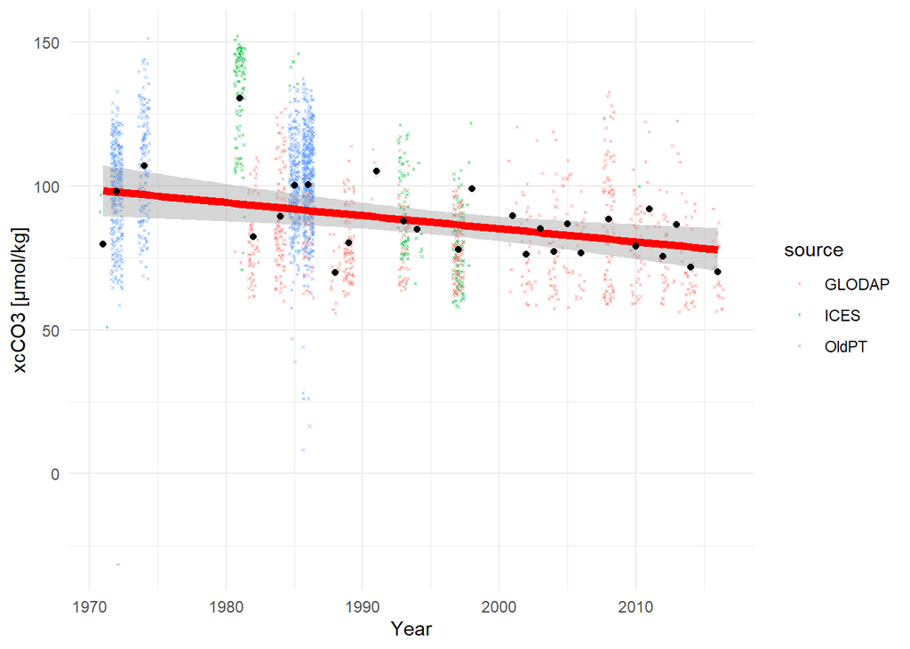

```r
ggplot(final_xcCO3, aes(G2year, xcCO3)) +
  geom_jitter(data = xcCO3, aes(colour = source), alpha = .7, shape = 4, size = .3) +
  geom_smooth(method = MASS::rlm, color = "red", size = 2) +
  geom_point() +
  theme_minimal() +
  labs(x = "Year", y = "xcCO3 [μmol/kg]")
```

# PM trends step 5 - Plots

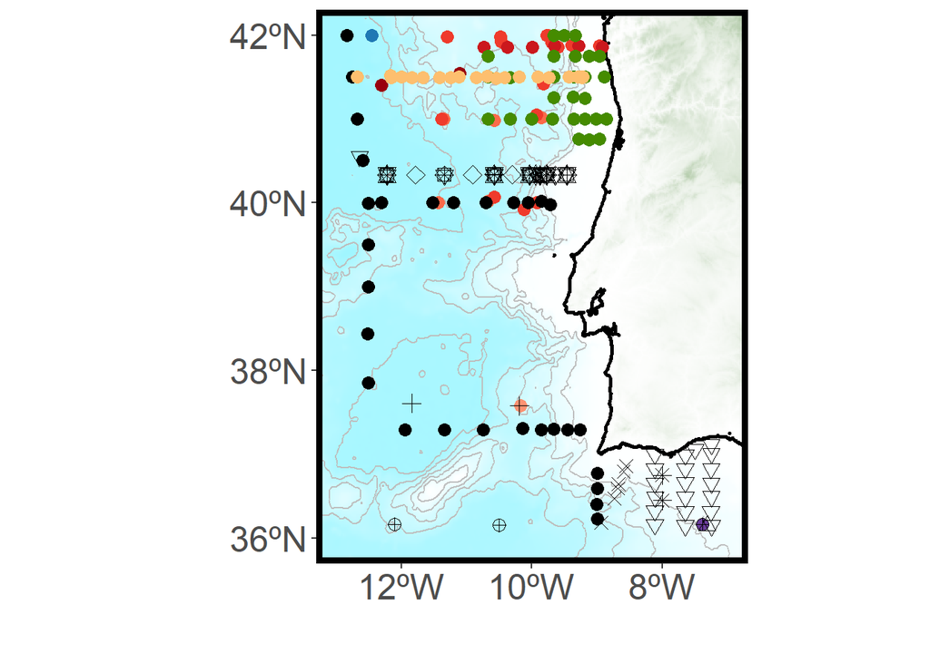

```r
# Still need to add colours and a legend

t0 <- Sys.time()

stations <- A %>%
  filter(!is.na(xcCO3)) %>%
  select(G2longitude, G2latitude, G2year) %>%
  distinct(G2longitude, G2latitude, .keep_all = TRUE)

m <- getNOAA.bathy(lon1 = ABasin[1, 1] - 4, lon2 = ABasin[2, 1] + 5,  # -4 and +5 what does it mean?
                     lat1 = ABasin[1, 2] -5 , lat2 = ABasin[2, 2] + 3, resolution = 1)  # 1 is the finest

(basemap <- ggplot(m, aes(x = x, y = y)) +
    coord_quickmap(xlim = c(-13, -7), ylim = c(36, 42)) +
    geom_raster(aes(fill = z)) +
    scale_fill_gradient2(low = "cadetblue1", mid = "white", high = "darkgreen", midpoint = 0, guide = F) +
    geom_contour(aes(z = z), breaks = c(-1000, -2000, -3000, -4000, -5000), colour = "gray", size = 0.5) +
    geom_contour(aes(z = z), breaks = c(0), colour = "black", size = 1) +
    geom_point(data = stations[stations$G2year == 1981, ], aes(x = G2longitude, y = G2latitude),
               size = 3, color = "#fc9272") +
    geom_point(data = stations[stations$G2year == 1982, ], aes(x = G2longitude, y = G2latitude),
               size = 3, color = "#fb6a4a") +
    geom_point(data = stations[stations$G2year == 1984, ], aes(x = G2longitude, y = G2latitude),
               size = 3, color = "#ef3b2c") +
    geom_point(data = stations[stations$G2year == 1986, ], aes(x = G2longitude, y = G2latitude),
               size = 3, color = "#cb181d") +
    geom_point(data = stations[stations$G2year == 1988, ], aes(x = G2longitude, y = G2latitude),
               size = 3, color = "#99000d") +
    geom_point(data = stations[stations$G2year == 1989, ], aes(x = G2longitude, y = G2latitude),
               size = 3, color = "black") +
    geom_point(data = stations[stations$G2year == 1991, ], aes(x = G2longitude, y = G2latitude),
               size = 3, color = "#1f78b4") +
    geom_point(data = stations[stations$G2year == 1993, ], aes(x = G2longitude, y = G2latitude),
               size = 3, color = "chartreuse4") +
    geom_point(data = stations[stations$G2year == 1997, ], aes(x = G2longitude, y = G2latitude),
               size = 3, color = "#fdbf6f") +
    geom_point(data = stations[stations$G2year == 2001, ], aes(x = G2longitude, y = G2latitude),
               size = 3, color = "#6a3d9a") +
    geom_point(data = stations[stations$G2year == 2002, ], aes(x = G2longitude, y = G2latitude),
               size = 3, shape = 1) +
    geom_point(data = stations[stations$G2year == 2003, ], aes(x = G2longitude, y = G2latitude),
               size = 3, shape = 2) +
    geom_point(data = stations[stations$G2year == 2004, ], aes(x = G2longitude, y = G2latitude),
               size = 3, shape = 3) +
    geom_point(data = stations[stations$G2year == 2005, ], aes(x = G2longitude, y = G2latitude),
               size = 3, shape = 4) +
    geom_point(data = stations[stations$G2year == 2006, ], aes(x = G2longitude, y = G2latitude),
               size = 3, shape = 5) +
    geom_point(data = stations[stations$G2year == 2008, ], aes(x = G2longitude, y = G2latitude),
               size = 3, shape = 6) +
    geom_point(data = stations[stations$G2year == 2010, ], aes(x = G2longitude, y = G2latitude),
               size = 3, shape = 7) +
    geom_point(data = stations[stations$G2year == 2011, ], aes(x = G2longitude, y = G2latitude),
               size = 3, shape = 8) +
    geom_point(data = stations[stations$G2year == 2012, ], aes(x = G2longitude, y = G2latitude),
               size = 3, shape = 9) +
    geom_point(data = stations[stations$G2year == 2013, ], aes(x = G2longitude, y = G2latitude),
               size = 3, shape = 10) +
    geom_point(data = stations[stations$G2year == 2014, ], aes(x = G2longitude, y = G2latitude),
               size = 3, shape = 11) +
    geom_point(data = stations[stations$G2year == 2016, ], aes(x = G2longitude, y = G2latitude),
               size = 3, shape = 12) +
    scale_shape_manual(values = seq(15, 25)) +  # what does this line do?
    scale_x_continuous(breaks = c(-8, -10, -12), labels = c("8ºW", "10ºW", "12ºW")) +
    scale_y_continuous(breaks = c(36, 38, 40, 42), labels = c("36ºN", "38ºN", "40ºN", "42ºN")) +
    labs(x = "", y = "") +
    theme(
      panel.border = element_rect(colour = "black", fill = NA, size = 3),
      text = element_text(size = 24, colour = "black"),
      legend.title = element_blank())
)
```

```r
savefigure = 0
if (savefigure) {
ggsave(filename = "PMtrends_map.pdf",
       plot = basemap, dpi = 300, width = 20, height = 23, units = "cm")
}

abrirfigura = 0
if (abrirfigura) {
  shell.exec("PMtrends_map.pdf")
}
```

# PM trends step 6 - Tables

```r
# All zones
trend_array <- c(trend_pH, trend_Cant, trend_xcCO3)
error_array <- c(etrend_pH, etrend_Cant, etrend_xcCO3)
pvalue_array <- c(pvalue_pH, pvalue_Cant, pvalue_xcCO3)

trend_array_G2 <- c(trend_pH_G2, trend_Cant_G2, trend_xcCO3_G2)
error_array_G2 <- c(etrend_pH_G2, etrend_Cant_G2, etrend_xcCO3_G2)
pvalue_array_G2 <- c(pvalue_pH_G2, pvalue_Cant_G2, pvalue_xcCO3_G2)

trend_array_NN <- c(trend_pH_NN, trend_Cant_NN, trend_xcCO3_NN)
error_array_NN <- c(etrend_pH_NN, etrend_Cant_NN, etrend_xcCO3_NN)
pvalue_array_NN <- c(pvalue_pH_NN, pvalue_Cant_NN, pvalue_xcCO3_NN)

# Zone 1
trend_array_1 <- c(trend_pH_1, trend_Cant_1, trend_xcCO3_1)
error_array_1 <- c(etrend_pH_1, etrend_Cant_1, etrend_xcCO3_1)
pvalue_array_1 <- c(pvalue_pH_1, pvalue_Cant_1, pvalue_xcCO3_1)

trend_array_G2_1 <- c(trend_pH_G2_1, trend_Cant_G2_1, trend_xcCO3_G2_1)
error_array_G2_1 <- c(etrend_pH_G2_1, etrend_Cant_G2_1, etrend_xcCO3_G2_1)
pvalue_array_G2_1 <- c(pvalue_pH_G2_1, pvalue_Cant_G2_1, pvalue_xcCO3_G2_1)

trend_array_NN_1 <- c(trend_pH_NN_1, trend_Cant_NN_1, trend_xcCO3_NN_1)
error_array_NN_1 <- c(etrend_pH_NN_1, etrend_Cant_NN_1, etrend_xcCO3_NN_1)
pvalue_array_NN_1 <- c(pvalue_pH_NN_1, pvalue_Cant_NN_1, pvalue_xcCO3_NN_1)

# Zone 2
trend_array_2 <- c(trend_pH_2, trend_Cant_2, trend_xcCO3_2)
error_array_2 <- c(etrend_pH_2, etrend_Cant_2, etrend_xcCO3_2)
pvalue_array_2 <- c(pvalue_pH_2, pvalue_Cant_2, pvalue_xcCO3_2)

trend_array_G2_2 <- c(trend_pH_G2_2, trend_Cant_G2_2, trend_xcCO3_G2_2)
error_array_G2_2 <- c(etrend_pH_G2_2, etrend_Cant_G2_2, etrend_xcCO3_G2_2)
pvalue_array_G2_2 <- c(pvalue_pH_G2_2, pvalue_Cant_G2_2, pvalue_xcCO3_G2_2)

trend_array_NN_2 <- c(trend_pH_NN_2, trend_Cant_NN_2, trend_xcCO3_NN_2)
error_array_NN_2 <- c(etrend_pH_NN_2, etrend_Cant_NN_2, etrend_xcCO3_NN_2)
pvalue_array_NN_2 <- c(pvalue_pH_NN_2, pvalue_Cant_NN_2, pvalue_xcCO3_NN_2)

# Zone 3
trend_array_3 <- c(trend_pH_3, trend_Cant_3, trend_xcCO3_3)
error_array_3 <- c(etrend_pH_3, etrend_Cant_3, etrend_xcCO3_3)
pvalue_array_3 <- c(pvalue_pH_3, pvalue_Cant_3, pvalue_xcCO3_3)

trend_array_G2_3 <- c(trend_pH_G2_3, trend_Cant_G2_3, trend_xcCO3_G2_3)
error_array_G2_3 <- c(etrend_pH_G2_3, etrend_Cant_G2_3, etrend_xcCO3_G2_3)
pvalue_array_G2_3 <- c(pvalue_pH_G2_3, pvalue_Cant_G2_3, pvalue_xcCO3_G2_3)

trend_array_NN_3 <- c(trend_pH_NN_3, trend_Cant_NN_3, trend_xcCO3_NN_3)
error_array_NN_3 <- c(etrend_pH_NN_3, etrend_Cant_NN_3, etrend_xcCO3_NN_3)
pvalue_array_NN_3 <- c(pvalue_pH_NN_3, pvalue_Cant_NN_3, pvalue_xcCO3_NN_3)

cols <- c("Trend", "Error", "p-value", "GLODAP Trend", "GLODAP Error", "GLODAP p-value",
          "NN Trend", "NN Error", "NN p-value")
rows <- c("pH", "Cant", "xcCO3", "pH zone 1", "Cant zone 1", "xcCO3 zone 1",
          "pH zone 2", "Cant zone 2", "xcCO3 zone 2", "pH zone 3", "Cant zone 3", "xcCO3 zone 3")

(trend_matrix <-
  matrix(
    data = c(trend_array, trend_array_1, trend_array_2, trend_array_3, error_array, error_array_1, error_array_2, error_array_3, pvalue_array, pvalue_array_1, pvalue_array_2, pvalue_array_3, trend_array_G2, trend_array_G2_1, trend_array_G2_2, trend_array_G2_3, error_array_G2, error_array_G2_1, error_array_G2_2, error_array_G2_3, pvalue_array_G2, pvalue_array_G2_1, pvalue_array_G2_2, pvalue_array_G2_3, trend_array_NN, trend_array_NN_1, trend_array_NN_2, trend_array_NN_3, error_array_NN, error_array_NN_1, error_array_NN_2, error_array_NN_3, pvalue_array_NN, pvalue_array_NN_1, pvalue_array_NN_2, pvalue_array_NN_3),
    nrow = 12,
    ncol = 9,
    dimnames = list(rows, cols)
  ))
```

```
##                     Trend        Error       p-value  GLODAP Trend GLODAP Error
## pH           -0.001672418 0.0002359968  1.374335e-12 -0.0012491660 0.0001868043
## Cant          0.671490965 0.0332596342  1.214097e-90  0.6599434797 0.0574532210
## xcCO3        -0.494950763 0.1529958742  1.216174e-03 -0.2359140416 0.1246028196
## pH zone 1    -0.001934734 0.0002012344  6.955877e-22 -0.0015102813 0.0001340067
## Cant zone 1   0.675577039 0.0224299431 2.697770e-199  0.6425755999 0.0379493522
## xcCO3 zone 1 -0.580858361 0.1001783022  6.701242e-09 -0.3827953798 0.0556422999
## pH zone 2    -0.001251582 0.0007602656  9.971380e-02 -0.0005802951 0.0006677200
## Cant zone 2   0.608341713 0.1318259160  3.935966e-06  0.9427616461 0.7308490945
## xcCO3 zone 2 -0.423483021 0.4069001183  2.979896e-01  0.0175078804 0.2830217539
## pH zone 3    -0.001569737 0.0004185091  1.762836e-04 -0.0004446547 0.0005406337
## Cant zone 3   0.732513894 0.0405067547  4.279872e-73  0.9772373836          NaN
## xcCO3 zone 3 -0.435950113 0.2078457408  3.595203e-02  0.3397847379 0.1972743755
##              GLODAP p-value      NN Trend     NN Error    NN p-value
## pH             2.277422e-11 -0.0017088318 0.0008671427  4.876432e-02
## Cant           1.540159e-30  0.7651488947 0.0249970218 9.120153e-206
## xcCO3          5.831423e-02 -0.5743707732 0.4902929154  2.414039e-01
## pH zone 1      1.841704e-29 -0.0014043629 0.0004129596  6.720686e-04
## Cant zone 1    2.593458e-64  0.7109506163 0.0759273758  7.709360e-21
## xcCO3 zone 1   6.003135e-12 -0.2441537020 0.3498169558  4.852103e-01
## pH zone 2      3.848091e-01 -0.0006945665 0.0009989283  4.868600e-01
## Cant zone 2    1.970667e-01  0.6961578305 0.0840070700  1.162425e-16
## xcCO3 zone 2   9.506739e-01 -0.3980918065 0.5342187228  4.561599e-01
## pH zone 3      4.108097e-01 -0.0017176101 0.0017424993  3.242723e-01
## Cant zone 3             NaN  0.7878381126 0.0123751099  0.000000e+00
## xcCO3 zone 3   8.499768e-02 -0.4738491044 0.9418323461  6.148841e-01
```